# Integrating 6 dpf WBIS batches

Alexandria Hughes

9/7/2021 - 10/7/2021

## WBIS overview

Copied WBIS_AH_filtered from WBIS share data with the following modifications:

- Filtered data to keep only zv11 for each main folder
- Deleted cloupe.cloupe for each
- Some folders have unfiltered_bc_matrices; deleted to keep only filtered_bc_matrices
- Making the assumption now that individual main branch folders are biological replicates and none of these are technical reps or reruns of the same cells or anything else not independent (can easily fix later; espec _oldkit _newkit named folders)
- 15 folders
- within zv11 eliminated unzipped mtx and tsv files (kept only gzipped .gz for all)

### Libraries

```r
library(tidyverse)

#bioconductor packages: install with bioclite manager
library(SingleCellExperiment)
library(BiocSingular)
library(igraph)
library(batchelor)
library(scater)
library(scran)

#cran packages: install.packages('uwot')
library(uwot)
library(patchwork)
```

## Bring in each dataset in, expand to sparse, and convert to SingleCellExperiment object

This is pretty repetitive with 15 datasets so write a function, `dir_to_sce` that will take care of this for each matrix directory, then run on each directory

#### dir_to_sce function

```r
dir_to_sce <- function(matdir, scename){
  barcode.path = paste0(matdir, "barcodes.tsv.gz")
  features.path = paste0(matdir, "features.tsv.gz")
  matrix.path = paste0(matdir, "matrix.mtx.gz")

  mat <- readMM(matrix.path)

  feature.names <- read.delim(features.path,
                           header = FALSE,
                           stringsAsFactors = FALSE)
  barcode.names <- read.delim(barcode.path,
                           header = FALSE,
                           stringsAsFactors = FALSE)

  colnames(mat) <- barcode.names$V1
  rownames(mat) <- feature.names$V2

  scename <- SingleCellExperiment(assays = list(counts = mat))
  rm(mat)

  return(scename)
}
```

### run dir_to_sce

Make all 15 sce objects - folder organization made this obnoxious to loop through:

```r
sce_2017_1001_10k <- dir_to_sce("WBIS_AH_filtered/2017_1001_10k/zv11/filtered_feature_bc_matrix/")
sce_2017_1001_3k <- dir_to_sce("WBIS_AH_filtered/2017_1001_3k/zv11/filtered_feature_bc_matrix/")
sce_2018_0301_actD <- dir_to_sce("WBIS_AH_filtered/2018_0301_actD/zv11/filtered_feature_bc_matrix/")
sce_2018_0608_xa195_3tg <- dir_to_sce("WBIS_AH_filtered/2018_0608_xa195_3tg/zv11/filtered_feature_bc_matrix/")
sce_2018_0815_xa104_3tg <- dir_to_sce("WBIS_AH_filtered/2018_0815_xa104_3tg/zv11/filtered_feature_bc_matrix/")
sce_2018_0815_xa224_3tg <- dir_to_sce("WBIS_AH_filtered/2018_0815_xa224_3tg/zv11/filtered_feature_bc_matrix/")
sce_2018_0815_xa244_3tg <- dir_to_sce("WBIS_AH_filtered/2018_0815_xa244_3tg/zv11/filtered_feature_bc_matrix/")
sce_2018_0815_xa395_3tg <- dir_to_sce("WBIS_AH_filtered/2018_0815_xa395_3tg/zv11/filtered_feature_bc_matrix/")
sce_2018_0815_xa68_3tg <- dir_to_sce("WBIS_AH_filtered/2018_0815_xa68_3tg/zv11/filtered_feature_bc_matrix/")
sce_2019_0627_HBSS <- dir_to_sce("WBIS_AH_filtered/2019_0627_HBSS/zv11/filtered_feature_bc_matrix/")
sce_2019_0627_PBS <- dir_to_sce("WBIS_AH_filtered/2019_0627_PBS/zv11/filtered_feature_bc_matrix/")
sce_2019_0820_TTT_newkit <- dir_to_sce("WBIS_AH_filtered/2019_0820_TTT_newkit/zv11/filtered_feature_bc_matrix/")
sce_2019_0820_TTT_oldkit <- dir_to_sce("WBIS_AH_filtered/2019_0820_TTT_oldkit/zv11/filtered_feature_bc_matrix/")
sce_2019_0820_xa74_TTT_newkit <- dir_to_sce("WBIS_AH_filtered/2019_0820_xa74_TTT_newkit/zv11/filtered_feature_bc_matrix/")
sce_2019_0820_xa74_TTT_oldkit <- dir_to_sce("WBIS_AH_filtered/2019_0820_xa74_TTT_oldkit/zv11/filtered_feature_bc_matrix/")
```

Make of list of these sces so we can use lapply later instead of loops:

```r
sce_list <- list(sce_2017_1001_10k, sce_2017_1001_3k, sce_2018_0301_actD, sce_2018_0608_xa195_3tg, sce_2018_0815_xa104_3tg, sce_2018_0815_xa224_3tg, sce_2018_0815_xa244_3tg, sce_2018_0815_xa395_3tg, sce_2018_0815_xa68_3tg, sce_2019_0627_HBSS, sce_2019_0627_PBS, sce_2019_0820_TTT_newkit, sce_2019_0820_TTT_oldkit, sce_2019_0820_xa74_TTT_newkit, sce_2019_0820_xa74_TTT_oldkit)
```

### 1. Quality control

An important pre-check is whether all of the sce objects are using the same gene list

```r
length(rownames(sce_2017_1001_10k)) #genes are the rows so rownames=genes
```

```
## [1] 32526
```

```r
length(rownames(sce_2017_1001_3k))
```

```
## [1] 32526
```

```r
length(intersect(rownames(sce_2017_1001_10k), rownames(sce_2017_1001_3k)))
```

```
## [1] 29074
```

**Although these two sces have the same number of genes, they are not the same genes! Only 29074/32526 overlap (all are zv11 so this is odd). Let’s expand this intersection to all 15 sces and subset each sce to keep the common genes only.

intersect() apparently only takes two arguments, but general with: Reduce(intersect, list(rownames(), rownames(),…))

```r
commongenes <- Reduce(intersect, list(rownames(sce_2017_1001_10k), rownames(sce_2017_1001_3k), rownames(sce_2018_0301_actD), rownames(sce_2018_0608_xa195_3tg), rownames(sce_2018_0815_xa104_3tg), rownames(sce_2018_0815_xa224_3tg), rownames(sce_2018_0815_xa244_3tg), rownames(sce_2018_0815_xa395_3tg), rownames(sce_2018_0815_xa68_3tg), rownames(sce_2019_0627_HBSS), rownames(sce_2019_0627_PBS), rownames(sce_2019_0820_TTT_newkit), rownames(sce_2019_0820_TTT_oldkit), rownames(sce_2019_0820_xa74_TTT_newkit), rownames(sce_2019_0820_xa74_TTT_oldkit)))

length(commongenes)
```

```
## [1] 29074
```

Subset: to do this with a list the output has to be a list, also (here newList)

```r
newList = lapply(sce_list, function(x)
  {x[commongenes,]
  } )
```

```r
newList[1]
```

```
## [[1]]
## class: SingleCellExperiment
## dim: 29074 7183
## metadata(0):
## assays(1): counts
## rownames(29074): DsRed GFP ... LAMP5 CABZ01109058.1
## rowData names(0):
## colnames(7183): AAACCTGAGAAACCAT-1 AAACCTGAGAAGGCCT-1 ...
##   TTTGTCATCTTCTGGC-1 TTTGTCATCTTTAGTC-1
## colData names(0):
## reducedDimNames(0):
## mainExpName: NULL
## altExpNames(0):
```

```r
is.mito <- grepl("^mt-", commongenes)
```

```r
qclist = lapply(newList, function(x){perCellQCMetrics(x, subsets=list(Mito=is.mito))})
filtlist = lapply(qclist, function(x){quickPerCellQC(x, percent_subsets="subsets_Mito_percent")})
```

want to take each element of newList and add a column, $discard, from the same-index corresponding element in filtlist

```r
for(i in 1:length(newList)){
  newList[[i]]$discard <- filtlist[[i]]$discard
}
```

```r
#newList[[1]]
#length(newList)
newList[[1]]
```

```
## class: SingleCellExperiment
## dim: 29074 7183
## metadata(0):
## assays(1): counts
## rownames(29074): DsRed GFP ... LAMP5 CABZ01109058.1
## rowData names(0):
## colnames(7183): AAACCTGAGAAACCAT-1 AAACCTGAGAAGGCCT-1 ...
##   TTTGTCATCTTCTGGC-1 TTTGTCATCTTTAGTC-1
## colData names(1): discard
## reducedDimNames(0):
## mainExpName: NULL
## altExpNames(0):
```

!!data sets 5 and 6 may be identical!! Same n of T/F cells v unlikely

```r
for(i in 1:length(newList)){
  print(summary(newList[[i]]$discard))
}
```

```
##    Mode   FALSE    TRUE
## logical    6291     892
##    Mode   FALSE    TRUE
## logical    2025     338
##    Mode   FALSE    TRUE
## logical    5111     534
##    Mode   FALSE    TRUE
## logical    4065     154
##    Mode   FALSE    TRUE
## logical    1442     114
##    Mode   FALSE    TRUE
## logical    1442     114
##    Mode   FALSE    TRUE
## logical    1820     138
##    Mode   FALSE    TRUE
## logical     695      36
##    Mode   FALSE    TRUE
## logical    1115      97
##    Mode   FALSE    TRUE
## logical    4479     269
##    Mode   FALSE    TRUE
## logical    3836     302
##    Mode   FALSE    TRUE
## logical    2181     244
##    Mode   FALSE    TRUE
## logical     862      53
##    Mode   FALSE    TRUE
## logical    1601      97
##    Mode   FALSE    TRUE
## logical     569      28
```

This was weird because S4 objects are weird - keep all rows and only those columns (cells) with discard status false.

```r
postqclist = lapply(newList, function(x){x[,which(x$discard == FALSE)]})
```

It did not run over newList. newList still contains info about mito/discard status.

```r
postqclist[1]
```

```
## [[1]]
## class: SingleCellExperiment
## dim: 29074 6291
## metadata(0):
## assays(1): counts
## rownames(29074): DsRed GFP ... LAMP5 CABZ01109058.1
## rowData names(0):
## colnames(6291): AAACCTGAGAAACCAT-1 AAACCTGAGAAGGCCT-1 ...
##   TTTGTCATCTTCTGGC-1 TTTGTCATCTTTAGTC-1
## colData names(1): discard
## reducedDimNames(0):
## mainExpName: NULL
## altExpNames(0):
```

```r
newList[1]
```

```
## [[1]]
## class: SingleCellExperiment
## dim: 29074 7183
## metadata(0):
## assays(1): counts
## rownames(29074): DsRed GFP ... LAMP5 CABZ01109058.1
## rowData names(0):
## colnames(7183): AAACCTGAGAAACCAT-1 AAACCTGAGAAGGCCT-1 ...
##   TTTGTCATCTTCTGGC-1 TTTGTCATCTTTAGTC-1
## colData names(1): discard
## reducedDimNames(0):
## mainExpName: NULL
## altExpNames(0):
```

```r
for(i in 1:length(newList)){
  print(summary(postqclist[[i]]$discard))
}
```

```
##    Mode   FALSE
## logical    6291
##    Mode   FALSE
## logical    2025
##    Mode   FALSE
## logical    5111
##    Mode   FALSE
## logical    4065
##    Mode   FALSE
## logical    1442
##    Mode   FALSE
## logical    1442
##    Mode   FALSE
## logical    1820
##    Mode   FALSE
## logical     695
##    Mode   FALSE
## logical    1115
##    Mode   FALSE
## logical    4479
##    Mode   FALSE
## logical    3836
##    Mode   FALSE
## logical    2181
##    Mode   FALSE
## logical     862
##    Mode   FALSE
## logical    1601
##    Mode   FALSE
## logical     569
```

### 2. Normalization

```r
postnormlist = lapply(postqclist, logNormCounts)
```

```r
postnormlist[5]
```

```
## [[1]]
## class: SingleCellExperiment
## dim: 29074 1442
## metadata(0):
## assays(2): counts logcounts
## rownames(29074): DsRed GFP ... LAMP5 CABZ01109058.1
## rowData names(0):
## colnames(1442): AAACGGGCAGCTCCGA-1 AAACGGGGTTCGTGAT-1 ...
##   TTTGTCAGTTAAAGAC-1 TTTGTCATCAATCACG-1
## colData names(2): discard sizeFactor
## reducedDimNames(0):
## mainExpName: NULL
## altExpNames(0):
```

### 3. Highly variable gene selection

hvglist keeps hvgs separate for / unique to each batch

```r
declist = lapply(postnormlist, modelGeneVar)

#hvg <- getTopHVGs(dec, fdr.threshold = 0.05)

hvglist = lapply(declist, function(x){
  getTopHVGs(x, fdr.threshold = 0.05)
  })
```

```r
declist[1]
```

```
## [[1]]
## DataFrame with 29074 rows and 6 columns
##                       mean       total        tech          bio     p.value
##                  <numeric>   <numeric>   <numeric>    <numeric>   <numeric>
## DsRed           0.27706538  0.48226826  0.32087665   0.16139161 1.48985e-04
## GFP             1.44638583  2.66913523  1.20875641   1.46037882 1.83801e-18
## mCardinal       1.06626573  1.13863085  0.98936792   0.14926293 1.38973e-01
## Gal4            0.01057543  0.01489119  0.01268285   0.00220834 1.05254e-01
## Kaede           0.00128703  0.00463736  0.00154368   0.00309368 2.16712e-47
## ...                    ...         ...         ...          ...         ...
## CABZ01088864.1 0.001013537 0.000938822 0.001215648 -2.76826e-04  0.94924915
## CABZ01110379.1 0.000470128 0.000516954 0.000563878 -4.69237e-05  0.72522642
## CABZ01109604.1 0.000272108 0.000465803 0.000326370  1.39433e-04  0.00106198
## LAMP5          0.000480591 0.000452604 0.000576427 -1.23824e-04  0.93880234
## CABZ01109058.1 0.000000000 0.000000000 0.000000000  0.00000e+00         NaN
##                        FDR
##                  <numeric>
## DsRed          3.78581e-03
## GFP            3.96994e-16
## mCardinal      7.31889e-01
## Gal4           6.40315e-01
## Kaede          1.72132e-44
## ...                    ...
## CABZ01088864.1   1.0000000
## CABZ01110379.1   1.0000000
## CABZ01109604.1   0.0203179
## LAMP5            1.0000000
## CABZ01109058.1         NaN
```

Kinda dig the idea of showing highly variable gene names but this is messy in practice:

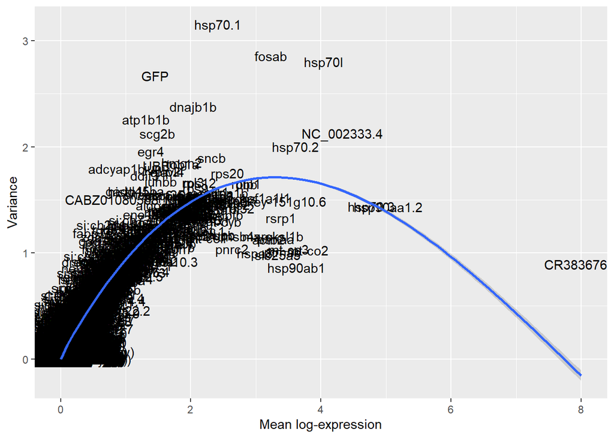

```r
sampledecdf <- as.data.frame(declist[1])

ggplot(sampledecdf, aes(x=mean, y=total, label=rownames(sampledecdf)))+
  geom_text()+
  geom_smooth()+
  labs(x="Mean log-expression",y="Variance")
```

How many PCs?

```r
#pctest <- denoisePCA(postnormlist[1], declist[1], subset.row=getTopHVGs(declist[1], fdr.threshold = 0.05))
#ncol(reducedDim(pctest, "PCA"))
```

### 4. Dim reduction

#### How many PCs? We’ll use denoisePCA() to select the number automatically for each batch

Test run since subsetting S4 objects is weird. Need two sets of brackets to grab from the list of 15 held in each of the relevant containers

```r
sce1 <- postnormlist[[1]] #this is the post-normalized list of sces
dec1 <- declist[[1]] #variable genes for each of the 15 sces
hvg1 <- hvglist[[1]] #highly (fdr.thresh 0.05) variable genes for each of the 15 sces
```

```r
pctest <- denoisePCA(sce1, dec1, subset.row=getTopHVGs(dec1, fdr.threshold = 0.05))
print(ncol(reducedDim(pctest, "PCA")))
```

```
## [1] 18
```

Do for all 15 and put number of PCs in a vector

```r
pcvec <- rep(0,15)

for(a in 1:15){
  pcp <- denoisePCA(postnormlist[[a]], declist[[a]], subset.row=getTopHVGs(declist[[a]], fdr.threshold = 0.05))
  pcvec[a] <- print(ncol(reducedDim(pcp, "PCA")))}
```

```
## [1] 18
## [1] 21
## [1] 20
## [1] 11
## [1] 27
## [1] 27
## [1] 19
## [1] 7
## [1] 24
## [1] 21
## [1] 22
## [1] 18
## [1] 16
## [1] 12
## [1] 13
```

```r
pcvec
```

```
##  [1] 18 21 20 11 27 27 19  7 24 21 22 18 16 12 13
```

#### runPCA and runUMAP loop

```r
for(a in 1:15){
  postnormlist[[a]] <- runPCA(postnormlist[[a]], ncomponents = pcvec[a], subset_row = hvglist[[a]])
  postnormlist[[a]] <- runUMAP(postnormlist[[a]], dimred = 'PCA', external_neighbors=TRUE)
}
```

fuck yes works great

```r
postnormlist[[2]]
```

```
## class: SingleCellExperiment
## dim: 29074 2025
## metadata(0):
## assays(2): counts logcounts
## rownames(29074): DsRed GFP ... LAMP5 CABZ01109058.1
## rowData names(0):
## colnames(2025): AAACCTGCACTGTTAG-1 AAACCTGGTCCAGTTA-1 ...
##   TTTGTCATCCGTCATC-1 TTTGTCATCGGATGGA-1
## colData names(2): discard sizeFactor
## reducedDimNames(2): PCA UMAP
## mainExpName: NULL
## altExpNames(0):
```

## *Load steps following this

*note to remove some of the unnecessary lists maybe

the sces can be cbind’d only if PC #s match or PCs are removed like this example

```r
 a <-postnormlist[[1]]
 b <- postnormlist[[10]]
#
# a$batch <- "batch1"
# b$batch <- "batch2"
#
# reducedDims(a) <- NULL
# reducedDims(b) <- NULL
#
# testcbind <- cbind(a,b)
```

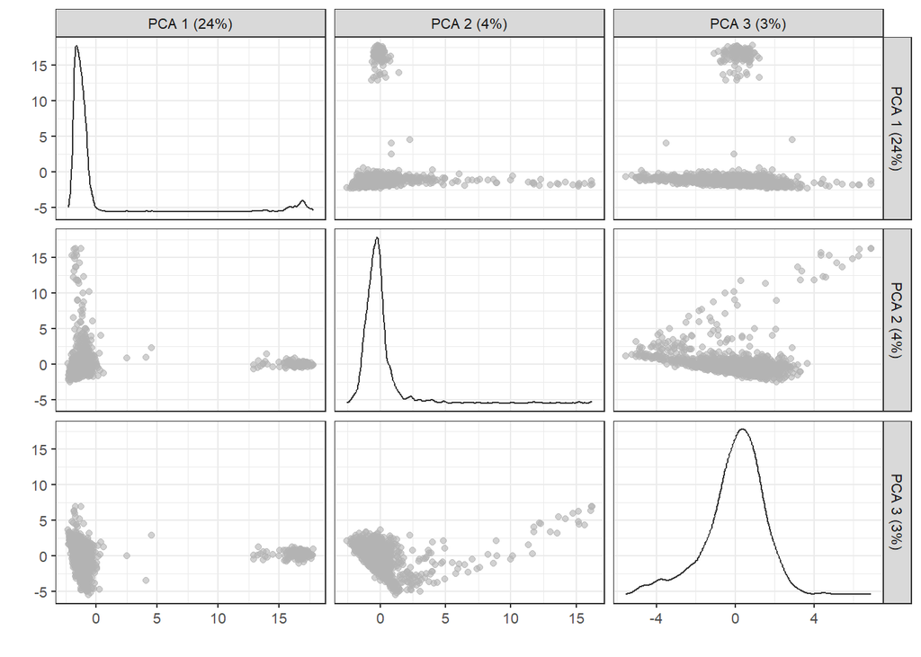

```r
plotPCA(postnormlist[[14]], ncomponents=3)
```

### 5. Clustering

```r
for(a in 1:length(postnormlist)){
  g <- buildSNNGraph(postnormlist[[a]], use.dimred = 'PCA')
  colLabels(postnormlist[[a]]) <- factor(igraph::cluster_louvain(g)$membership)
  }
```

```r
postnormlist[[2]]
```

```
## class: SingleCellExperiment
## dim: 29074 2025
## metadata(0):
## assays(2): counts logcounts
## rownames(29074): DsRed GFP ... LAMP5 CABZ01109058.1
## rowData names(0):
## colnames(2025): AAACCTGCACTGTTAG-1 AAACCTGGTCCAGTTA-1 ...
##   TTTGTCATCCGTCATC-1 TTTGTCATCGGATGGA-1
## colData names(3): discard sizeFactor label
## reducedDimNames(2): PCA UMAP
## mainExpName: NULL
## altExpNames(0):
```

### 6. Vis

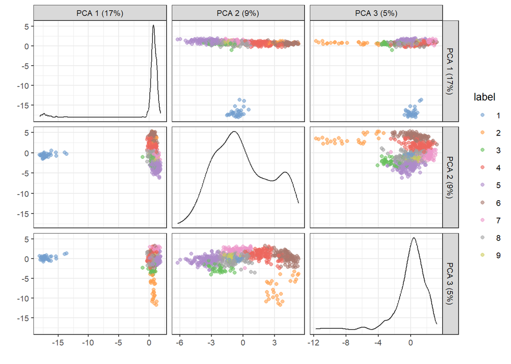

```r
plotPCA(postnormlist[[8]], ncomponents = 3, colour_by = "label")
```

Noted earlier (discard status table) but evident here, too: data sets 5 and 6 are the same

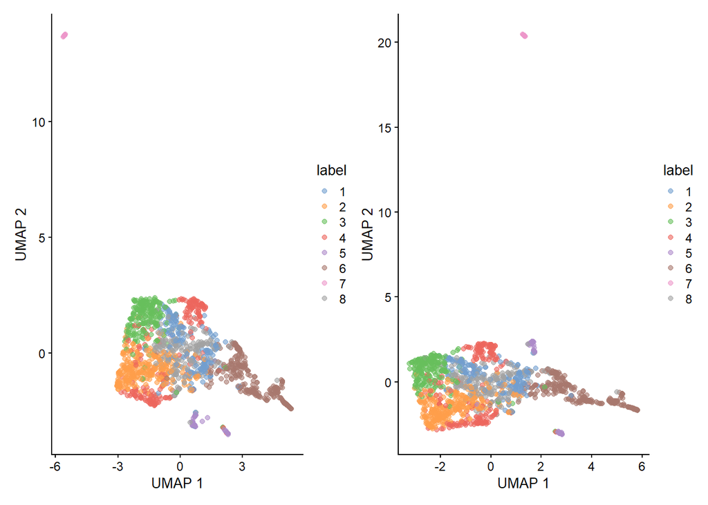

```r
plotUMAP(postnormlist[[5]], colour_by = "label") + plotUMAP(postnormlist[[6]], colour_by = "label")
```

## Find batch effects: uncorrected merge

Here we start from the post-QC data, label batches then merge into one, normalize, hvg, dim red, clustering and vis with batches labeled. This should be the ‘same’ as previous 6 dpf analysis but this time we know the batch identities.

merge the data (will need to normalize again, but this needs to happen pre-PCA because each sce object had a different number of PCs)

```r
postqclist[[1]]$batch <- "wbis_1"
postqclist[[2]]$batch <- "wbis_2"
postqclist[[3]]$batch <- "wbis_3"
postqclist[[4]]$batch <- "wbis_4"
postqclist[[5]]$batch <- "wbis_5"
postqclist[[7]]$batch <- "wbis_7"
postqclist[[8]]$batch <- "wbis_8"
postqclist[[9]]$batch <- "wbis_9"
postqclist[[10]]$batch <- "wbis_10"
postqclist[[11]]$batch <- "wbis_11"
postqclist[[12]]$batch <- "wbis_12"
postqclist[[13]]$batch <- "wbis_13"
postqclist[[14]]$batch <- "wbis_14"
postqclist[[15]]$batch <- "wbis_15"
```

```r
uncorrected_merge <- cbind(postqclist[[1]],postqclist[[2]],postqclist[[3]],postqclist[[4]],postqclist[[5]],postqclist[[7]],postqclist[[8]],postqclist[[9]],postqclist[[10]],postqclist[[11]],postqclist[[12]],postqclist[[13]],postqclist[[14]],postqclist[[15]])
```

### 2.2 Normalize

```r
uncorrected_merge <- logNormCounts(uncorrected_merge)
```

### 2.3 Feature selection

```r
decuncorr <- modelGeneVar(uncorrected_merge)
hvguncorr <- getTopHVGs(decuncorr, fdr.threshold = 0.05)
```

### 2.4 Dimred

#### How many PCs

```r
sced <- denoisePCA(uncorrected_merge, decuncorr, subset.row=getTopHVGs(decuncorr, fdr.threshold = 0.05))
npcs <- ncol(reducedDim(sced, "PCA"))
npcs
```

```
## [1] 16
```

```r
uncorrected_merge <- runPCA(uncorrected_merge, ncomponents=npcs, subset_row=hvguncorr)
uncorrected_merge <- runUMAP(uncorrected_merge, dimred = 'PCA', external_neighbors=TRUE)
```

### 2.5 Clustering

```r
set.seed(1357)
g <- buildSNNGraph(uncorrected_merge, use.dimred = 'PCA')
colLabels(uncorrected_merge) <- factor(igraph::cluster_louvain(g)$membership)
```

### 2.6 Vis

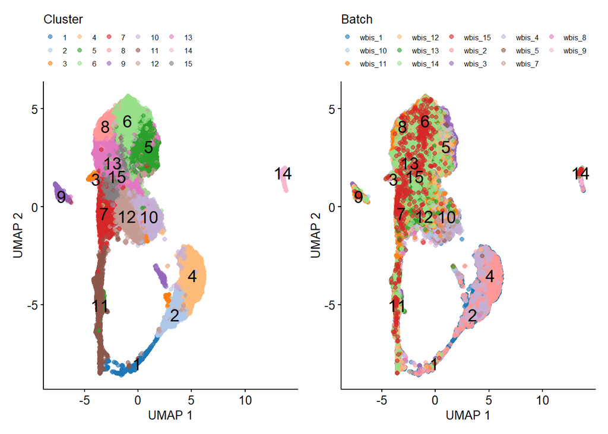

```r
a <-plotUMAP(uncorrected_merge, colour_by = "label", text_by = "label")+ #also did patchwork PCA
  theme(text = element_text(size=10),
        axis.text = element_text(size=10),
        legend.text=element_text(size=6),
        #legend.title = element_blank(),
        legend.position= "top")+
  guides(color=guide_legend(title="Cluster", title.position="top"))


b <- plotUMAP(uncorrected_merge, colour_by = "batch", text_by = "label")+
  theme(text = element_text(size=10),
        axis.text = element_text(size=10),
        legend.text=element_text(size=6),
        #legend.title = element_blank(),
        legend.position= "top")+
  guides(color=guide_legend(title="Batch", title.position="top"))

a + b
```

```r
ggsave('WBIS_AH_filtered/uncorr-umap-1-2-patchwork.png', dpi=300)
 # scale_color_discrete(labels =c ("1", "2","3", "4", "5", "6","7", "8", "9", "10", "11", "12", "13","14"))
```

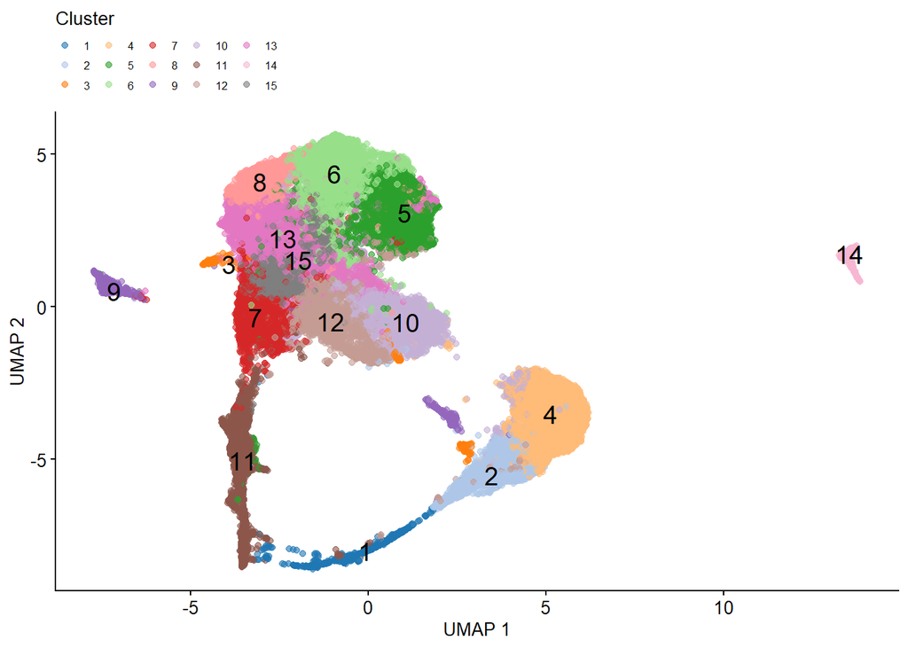

```r
plotUMAP(uncorrected_merge, colour_by = "label", text_by = "label")+
  theme(text = element_text(size=10),
        axis.text = element_text(size=10),
        legend.text=element_text(size=6),
        #legend.title = element_blank(),
        legend.position= "top")+
  guides(color=guide_legend(title="Cluster", title.position="top"))
```

```r
uncorrected_merge
```

```
## class: SingleCellExperiment
## dim: 29074 36092
## metadata(0):
## assays(2): counts logcounts
## rownames(29074): DsRed GFP ... LAMP5 CABZ01109058.1
## rowData names(0):
## colnames(36092): AAACCTGAGAAACCAT-1 AAACCTGAGAAGGCCT-1 ...
##   TTTGGTTCAAGCGTAG-1 TTTGGTTTCGTTTAGG-1
## colData names(4): discard batch sizeFactor label
## reducedDimNames(2): PCA UMAP
## mainExpName: NULL
## altExpNames(0):
```

Batch effect clear in 1st PC: notice striated batch coloration along 1st PC:

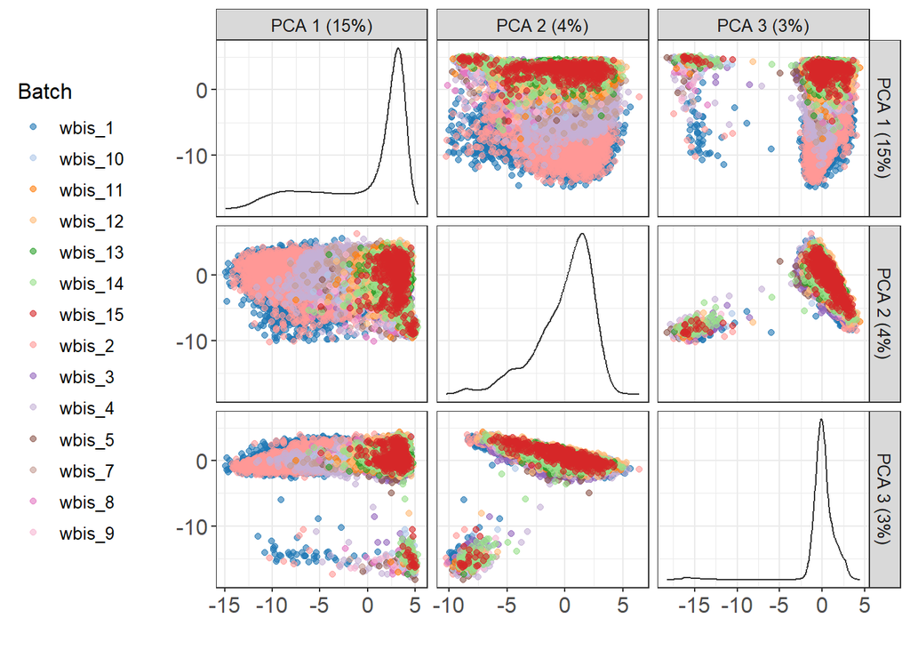

```r
plotPCA(uncorrected_merge, ncomponents=3, colour_by = "batch")+
  theme(text = element_text(size=12),
        axis.text = element_text(size=12),
       #legend.title = element_text("Batch"),
        legend.position= "left")+
  guides(color=guide_legend(title="Batch"))
```

```r
  #scale_color_discrete(labels =c ("1", "2","3", "4", "5", "6","7", "8", "9", "10", "11", "12", "13","14"))

#ggsave('WBIS_AH_filtered/uncorrmerge-PCA-3comp-batch.png', dpi=300)
```

```r
clustuncor <- igraph::cluster_louvain(g)$membership
```

```r
tabuncor <- table(Clusters=clustuncor, Batch=uncorrected_merge$batch)
tabuncor
```

```
##         Batch
## Clusters wbis_1 wbis_10 wbis_11 wbis_12 wbis_13 wbis_14 wbis_15 wbis_2 wbis_3
##       1     663       0       1       5       0       5       2    154      3
##       2    1589       1       0       0       0       0       0    525      0
##       3      98      58      36      11       3      28       5     32      4
##       4    3579       0       0       0       0       0       0   1176      0
##       5       4      64      81     142      29      95      14      1   3323
##       6       1    1191    1036     524     103     367     130      2    462
##       7       0     565     471     232      68     102     114      0    110
##       8       1     324     251      35      11      96      23      3     61
##       9     116     219     176     109      12      34      20     38    109
##       10    137      32      34      16      12      13       9     51      1
##       11     29     228     217     259      62     136      67     15    665
##       12     30     359     306      63     180      98      20     18     66
##       13      0    1350    1168     451      50     364      63      1    220
```

[output cut: 19 more lines]

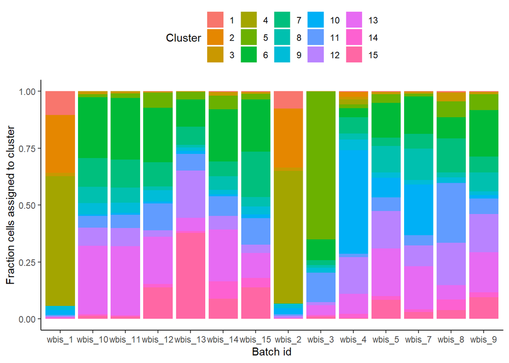

```r
as.data.frame(tabuncor) %>% ggplot(aes(x=Batch, Freq, fill=Clusters))+
  geom_bar(stat="identity", position="fill")+
  labs(x="Batch id", y="Fraction cells assigned to cluster", fill="Cluster")+
  theme_classic()+
  theme(legend.position = "top")
```

```r
vars <- getVarianceExplained(uncorrected_merge,
    variables=c("label", "batch", "sizeFactor"))
head(vars)
```

```
##                label      batch   sizeFactor
## DsRed      6.8552020  2.7470999 1.694117e-03
## GFP       22.6203509 16.3080569 1.138589e-01
## mCardinal 13.8759761 24.0738516 4.795251e-02
## Gal4       1.5327160  2.2831838 1.867671e-04
## Kaede      0.5935219  0.2731501 6.032827e-07
## mCherry    0.5076717  0.4100016 3.594638e-02
```

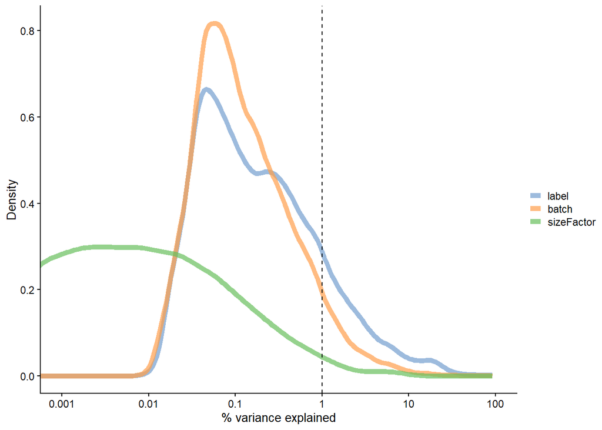

```r
plotExplanatoryVariables(vars)
```

## MNN batch correction

### 3.3 Feature selection

Choose the highly variable genes by averaging the variances of genes identified in each batch’s declist (modelGeneVar ran on each batch’s post-qc normed counts)

```r
combineddec <- combineVar(declist)
chosenhvgs <- combineddec$bio > 0
sum(chosenhvgs)
```

```
## [1] 15907
```

```r
combineddec
```

```
## DataFrame with 29074 rows and 7 columns
##                       mean       total        tech          bio      p.value
##                  <numeric>   <numeric>   <numeric>    <numeric>    <numeric>
## DsRed           0.12035329  0.19506649  0.14551056   0.04955593  2.42298e-23
## GFP             0.45454190  0.82238193  0.46159941   0.36078252  8.08531e-84
## mCardinal       0.60792620  0.67730378  0.64659246   0.03071132  1.44079e-01
## Gal4            0.00896553  0.01135785  0.01010961   0.00124824  3.25872e-02
## Kaede           0.00280903  0.00805977  0.00315857   0.00490120 4.39718e-322
## ...                    ...         ...         ...          ...          ...
## CABZ01088864.1 0.001078393 0.001176101 0.001323710 -1.47609e-04  9.98509e-01
## CABZ01110379.1 0.000342283 0.000408465 0.000442685 -3.42196e-05  2.18457e-11
## CABZ01109604.1 0.000541006 0.000844784 0.000716851  1.27934e-04  1.82581e-23
## LAMP5          0.000478071 0.000649525 0.000548142  1.01383e-04  1.18565e-14
## CABZ01109058.1 0.000000000 0.000000000 0.000000000  0.00000e+00           NA
##                         FDR
##                   <numeric>
## DsRed           3.03995e-22
## GFP             4.73969e-82
## mCardinal       2.44548e-01
## Gal4            6.32475e-02
## Kaede          8.30179e-320
## ...                     ...
## CABZ01088864.1  1.00000e+00
## CABZ01110379.1  1.24551e-10
## CABZ01109604.1  2.30657e-22
## LAMP5           8.74889e-14
## CABZ01109058.1           NA
##                                                                                                                                 per.block
##                                                                                                                               <DataFrame>
## DsRed                   0.27706538:0.48226826:0.32087665:...:0.26988291:0.4814121:0.31780112:...:0.00000000:0.00000000:0.00000000:...:...
## GFP                     1.44638583:2.66913523:1.20875641:...:1.41823733:3.1784398:1.23248028:...:0.00000000:0.00000000:0.00000000:...:...
## mCardinal               1.06626573:1.13863085:0.98936792:...:1.05667692:1.2002039:1.00793970:...:0.00000000:0.00000000:0.00000000:...:...
## Gal4                    0.01057543:0.01489119:0.01268285:...:0.01179998:0.0186911:0.01438103:...:0.06662826:0.08532240:0.07369750:...:...
## Kaede                   0.00128703:0.00463736:0.00154368:...:0.00540479:0.0219483:0.00658746:...:0.00530414:0.00630042:0.00588036:...:...
## ...                                                                                                                                   ...
## CABZ01088864.1 0.001013537:0.000938822:0.001215648:...:0.001167818:0.000956846:0.00142339:...:0.001416496:1.50869e-03:0.001570411:...:...
## CABZ01110379.1 0.000470128:0.000516954:0.000563878:...:0.000910309:0.001046893:0.00110953:...:0.000424647:9.21640e-04:0.000470789:...:...
## CABZ01109604.1 0.000272108:0.000465803:0.000326370:...:0.000000000:0.000000000:0.00000000:...:0.000219124:2.45406e-04:0.000242934:...:...
## LAMP5          0.000480591:0.000452604:0.000576427:...:0.000000000:0.000000000:0.00000000:...:0.000135348:9.36286e-05:0.000150055:...:...
## CABZ01109058.1 0.000000000:0.000000000:0.000000000:...:0.000000000:0.000000000:0.00000000:...:0.000000000:0.00000e+00:0.000000000:...:...
```

### 3.4 Dimred (Fast MNN)

```r
set.seed(1000101001)
mnn_6dpf <- fastMNN(postnormlist[[1]], postnormlist[[2]], postnormlist[[3]], postnormlist[[4]], postnormlist[[5]], postnormlist[[7]], postnormlist[[8]],postnormlist[[9]],postnormlist[[10]],postnormlist[[11]],postnormlist[[12]],postnormlist[[13]],postnormlist[[14]],postnormlist[[15]],
                  d=50, k=20, subset.row=chosenhvgs,
    BSPARAM=BiocSingular::RandomParam(deferred=TRUE))
mnn_6dpf
```

```
## class: SingleCellExperiment
## dim: 15907 36092
## metadata(2): merge.info pca.info
## assays(1): reconstructed
## rownames(15907): DsRed GFP ... CABZ01109604.1 LAMP5
## rowData names(1): rotation
## colnames(36092): AAACCTGAGAAACCAT-1 AAACCTGAGAAGGCCT-1 ...
##   TTTGGTTCAAGCGTAG-1 TTTGGTTTCGTTTAGG-1
## colData names(1): batch
## reducedDimNames(1): corrected
## mainExpName: NULL
## altExpNames(0):
```

### 3.5 Clustering

```r
snngrm <- buildSNNGraph(mnn_6dpf, use.dimred="corrected")
clustersmnn <- igraph::cluster_louvain(snngrm)$membership
colLabels(mnn_6dpf) <- factor(clustersmnn)
```

```r
tabmnn <- table(Cluster=clustersmnn, Batch=mnn_6dpf$batch)
tabmnn
```

```
##        Batch
## Cluster    1    2    3    4    5    6    7    8    9   10   11   12   13   14
##      1   222   61  428  353   98  144   13   78  586  555  195    3  203   31
##      2   673  165  602   63   83   73  172   81  196  184  257   58  130   68
##      3    73   23    2   17   15   16    8   11   24   11    4    3   10   13
##      4   987  304  149  420  104  166    6   60  419  316   62    1   73    7
##      5    43    9   30   78   24   22   32   23   23   17   32    7  120   23
##      6   884  310  491  563  140  278   35  116  665  570  204    7  154   29
##      7  1004  349 1112  651  463  321   72  315  357  357  724  618  386  182
##      8   741  257  760  689  153  164  149  153  385  321  144   42  133   17
##      9   230   75  477  223  164  278   15  109  529  369   80    5   96   29
##      10    8    4   38    2    2    3    2    0    2    3    4    6    2    0
##      11  964  344  693  520   89  211  120   75  745  637  249   50  111  114
##      12   90   25  198  216   31   69    8   45  260  275   96   13  108   27
##      13  118   44  108  198   36   31   18   17  210  165  103   14   30   20
##      14  143   22    6   13    1    1    1    0    2    5    5   32    1    4
##      15   11    0   11    2    7    6    3    8    5    7    8    0    2    0
##      16  100   33    6   57   32   37   41   24   71   44   14    3   42    5
```

```r
mnndf <- as.data.frame(tabmnn)
```

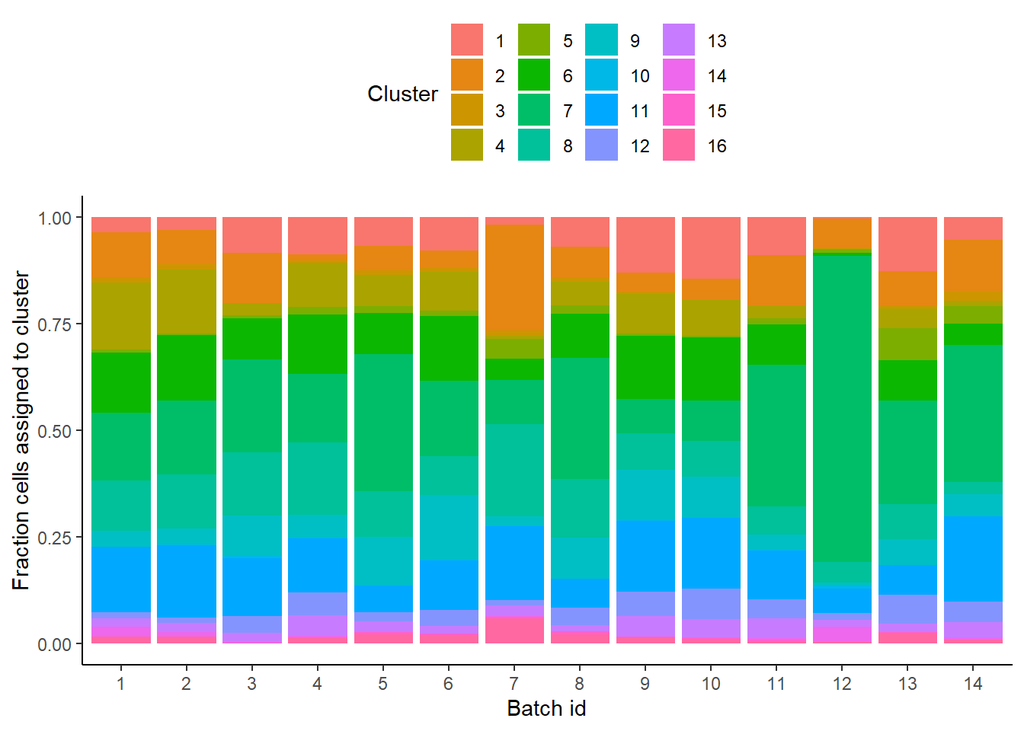

```r
ggplot(mnndf, aes(x=Batch, Freq, fill=Cluster))+
  geom_bar(stat="identity", position="fill")+
  labs(x="Batch id", y="Fraction cells assigned to cluster", fill="Cluster")+
  theme_classic()+
  theme(legend.position = "top")
```

### 3.6 Vis

```r
mnn_6dpf <- runUMAP(mnn_6dpf, dimred="corrected")
mnn_6dpf$batch <- factor(mnn_6dpf$batch)
```

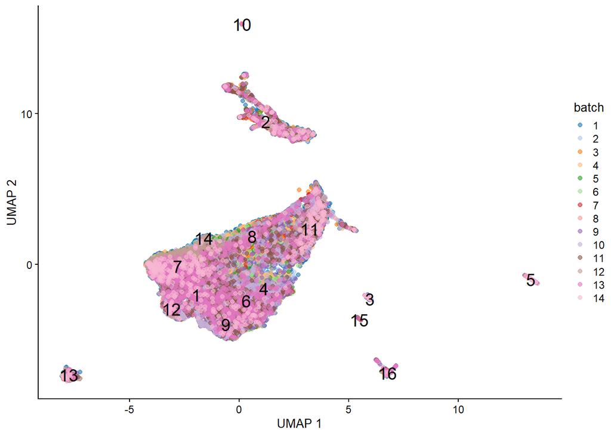

```r
plotUMAP(mnn_6dpf, colour_by = "batch", text_by = "label")
```

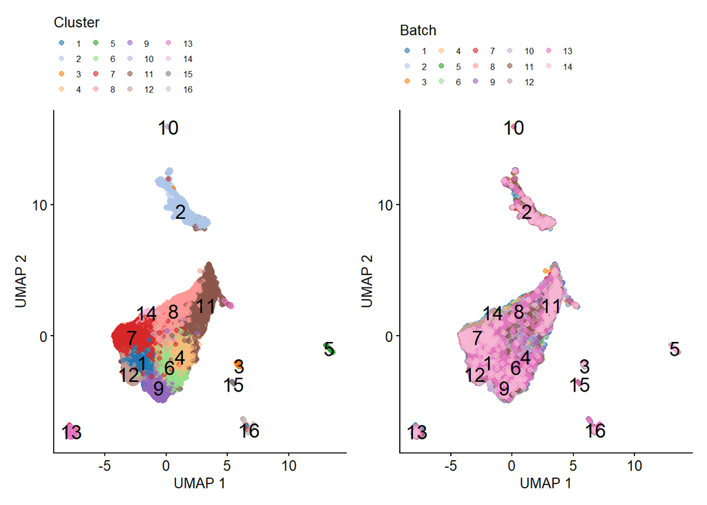

```r
c <-plotUMAP(mnn_6dpf, colour_by = "label", text_by = "label")+ #also did patchwork PCA
  theme(text = element_text(size=10),
        axis.text = element_text(size=10),
        legend.text=element_text(size=6),
        #legend.title = element_blank(),
        legend.position= "top")+
  guides(color=guide_legend(title="Cluster", title.position="top"))


d <- plotUMAP(mnn_6dpf, colour_by = "batch", text_by = "label")+
  theme(text = element_text(size=10),
        axis.text = element_text(size=10),
        legend.text=element_text(size=6),
        #legend.title = element_blank(),
        legend.position= "top")+
  guides(color=guide_legend(title="Batch", title.position="top"))

c + d
```

```r
#ggsave('WBIS_AH_filtered/WBIS-plots/mnn-1-2-patch-umap.png', dpi=300)
```

#### 3.6.2 Add counts back to cells

MNN discards counts and logcounts for genes that aren’t used for clustering and distorts the count information for those genes that are kept. To visualize counts on the MNN visualizations we would prefer to view original counts or logcounts rather than these distorted counts. Also, to identify marker genes for clusters, we need the original count data.

Note that plotUMAP(…, colour_by = “genename”) calls the original count data and will throw an error rather than display distorted count data, which is a nice feature.

```r
liluniverse <- intersect(rownames(uncorrected_merge), rownames(mnn_6dpf))
length(liluniverse)
```

```
## [1] 15907
```

```r
uncorr_for_mnn <- uncorrected_merge[liluniverse,]
assays(mnn_6dpf) <- assays(uncorr_for_mnn)
```

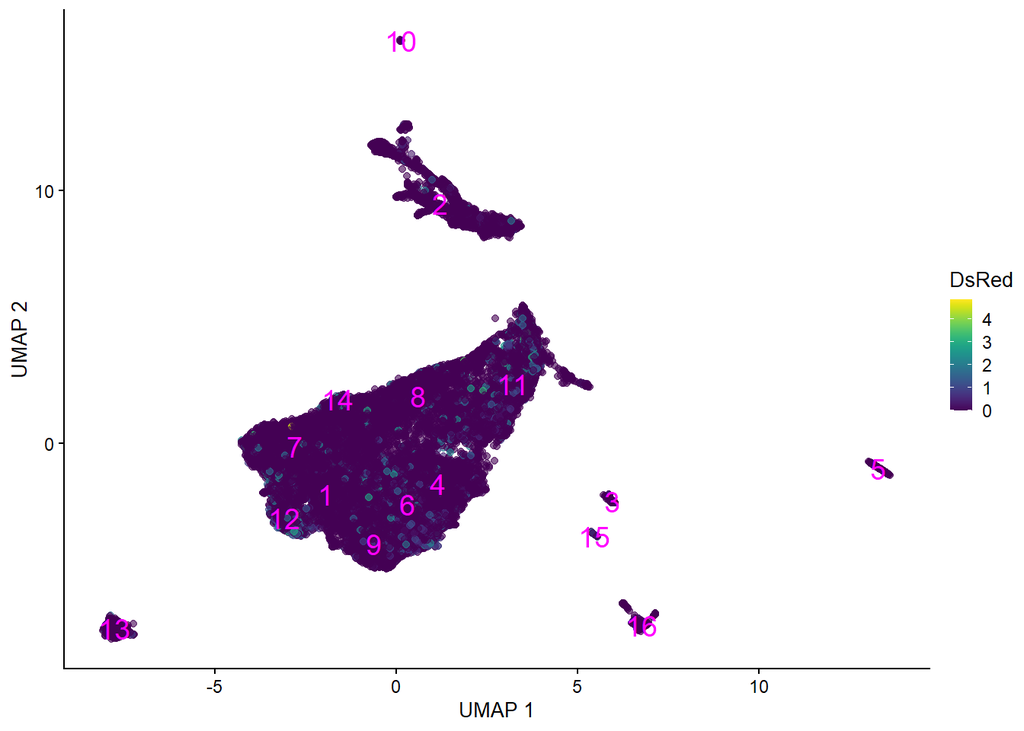

```r
plotUMAP(mnn_6dpf, colour_by = "DsRed", text_by = "label", text_colour = "magenta")
```

```r
#save.image(file = "WBIS_AH_filtered/2021-9-7.RData", compress = FALSE)
```

```r
#load("WBIS_AH_filtered/2021-9-7.RData")
```